# Tidyverse EXTEND Assignment

Puja Roy

4/28/24

### Objective

The goal of this assignment is to EXTEND a Vignette of a classmate’s CREATE Vignette from the Tidyverse Assignment GitHub Repository.

### EXTEND Vignette

For this assignment, I am going to EXTEND Atta Boateng’s Vignette. By extending the Vignette below, I will utilize ggplot to plot and customize the color of the plot based on the opening prices of other stock index types from the data.

Below is Atta Boateng’s Vignette:

“Using the data of stock data, I am going to demonstrate some of the capabilities of the tidyverse package. I start by first using the ggplot library to plot the opening prices of the New York Stock Exchange, noted by the symbol (NYA).” - Atta Boateng

```r
library(tidyverse)
library(openintro)
```

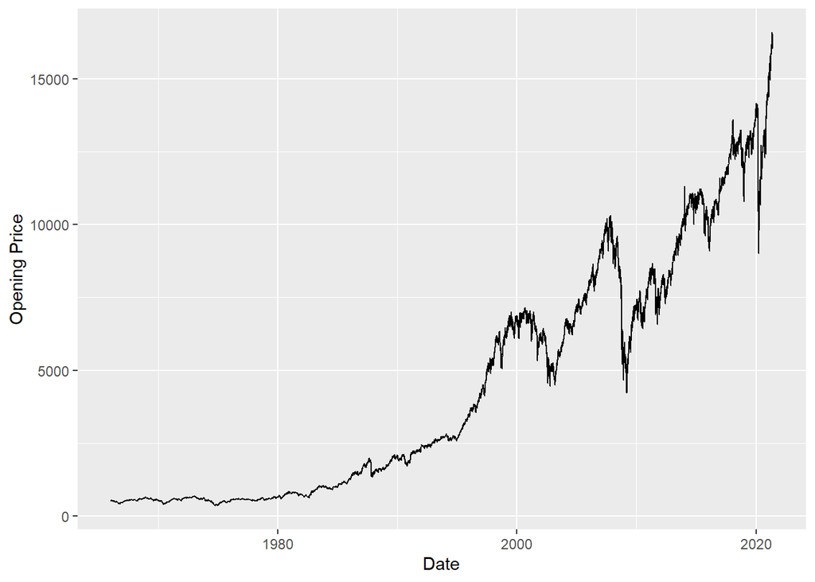

```r
dd <- read.csv("https://raw.githubusercontent.com/attaboatengsr/DATA607/main/Week9/indexData.csv", sep=",");
dd <- dd %>% filter(Index == "NYA" );

ggplot(data = dd, aes(x=as.Date(dd$Date) , y=as.numeric(dd$Open))) + geom_line()+ labs(x="Date", y="Opening Price")
```

“The ggplot function provides us with various graph options for our dataset. The function has a ‘data’ parameter and ‘mapping’ parameter. Additionally, witht the ‘+’ operators, one the include the type of graph they wish to plot.” - Atta Boateng

### EXTEND alternate Index Types of Stocks

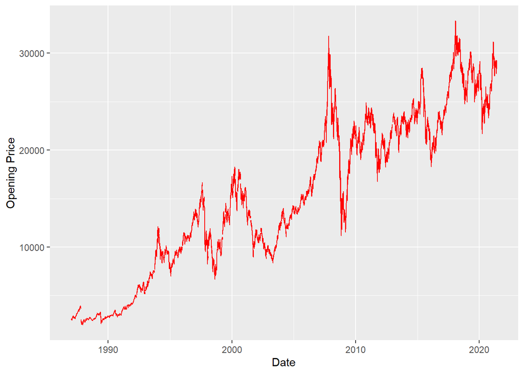

```r
dd <- read.csv("https://raw.githubusercontent.com/attaboatengsr/DATA607/main/Week9/indexData.csv", sep=",")
dd <- dd %>% filter(Index == "HSI")

ggplot(data = dd, aes(x=as.Date(dd$Date), y=as.numeric(dd$Open))) +
  geom_line(color="red") +
  labs(x="Date", y="Opening Price")
```

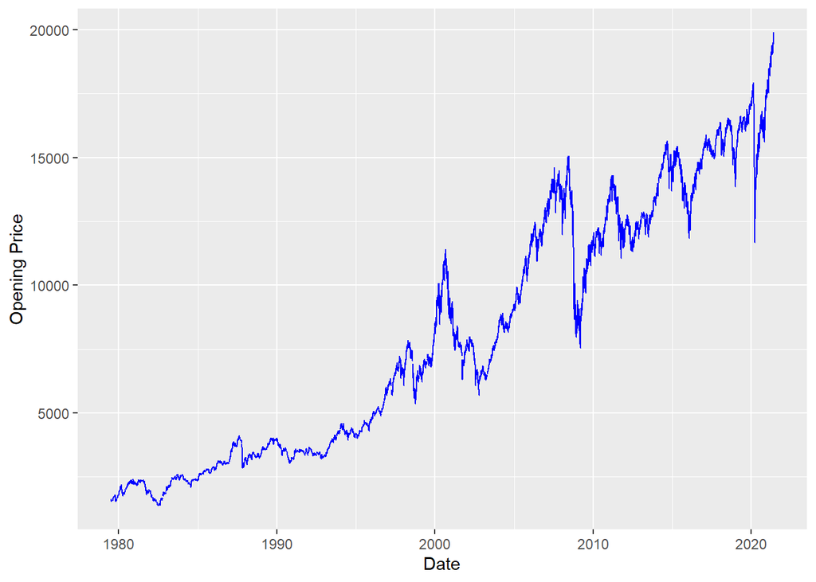

```r
dd <- read.csv("https://raw.githubusercontent.com/attaboatengsr/DATA607/main/Week9/indexData.csv", sep=",")
dd <- dd %>% filter(Index == "GSPTSE")

ggplot(data = dd, aes(x=as.Date(dd$Date), y=as.numeric(dd$Open))) +
  geom_line(color="blue") +
  labs(x="Date", y="Opening Price")
```

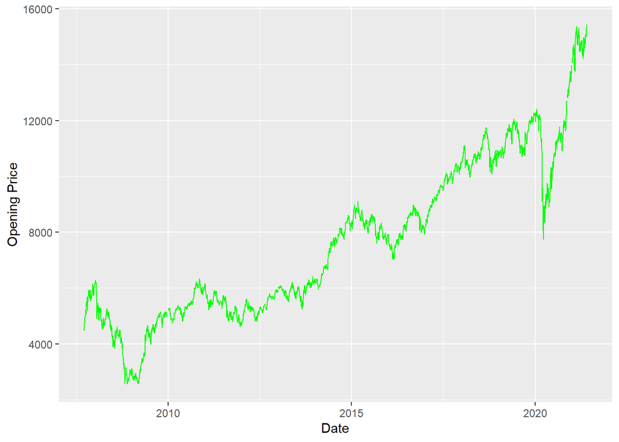

```r
dd <- read.csv("https://raw.githubusercontent.com/attaboatengsr/DATA607/main/Week9/indexData.csv", sep=",")
dd <- dd %>% filter(Index == "NSEI")

ggplot(data = dd, aes(x=as.Date(dd$Date), y=as.numeric(dd$Open))) +
  geom_line(color="green") +
  labs(x="Date", y="Opening Price")
```

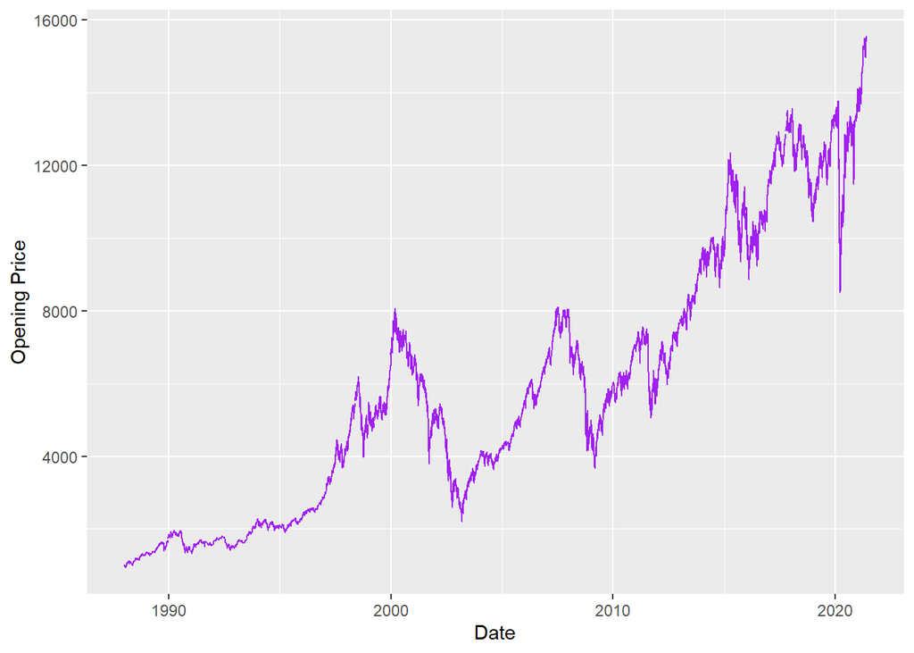

```r
dd <- read.csv("https://raw.githubusercontent.com/attaboatengsr/DATA607/main/Week9/indexData.csv", sep=",")
dd <- dd %>% filter(Index == "GDAXI")

ggplot(data = dd, aes(x=as.Date(dd$Date), y=as.numeric(dd$Open))) +
  geom_line(color="purple") +
  labs(x="Date", y="Opening Price")
```

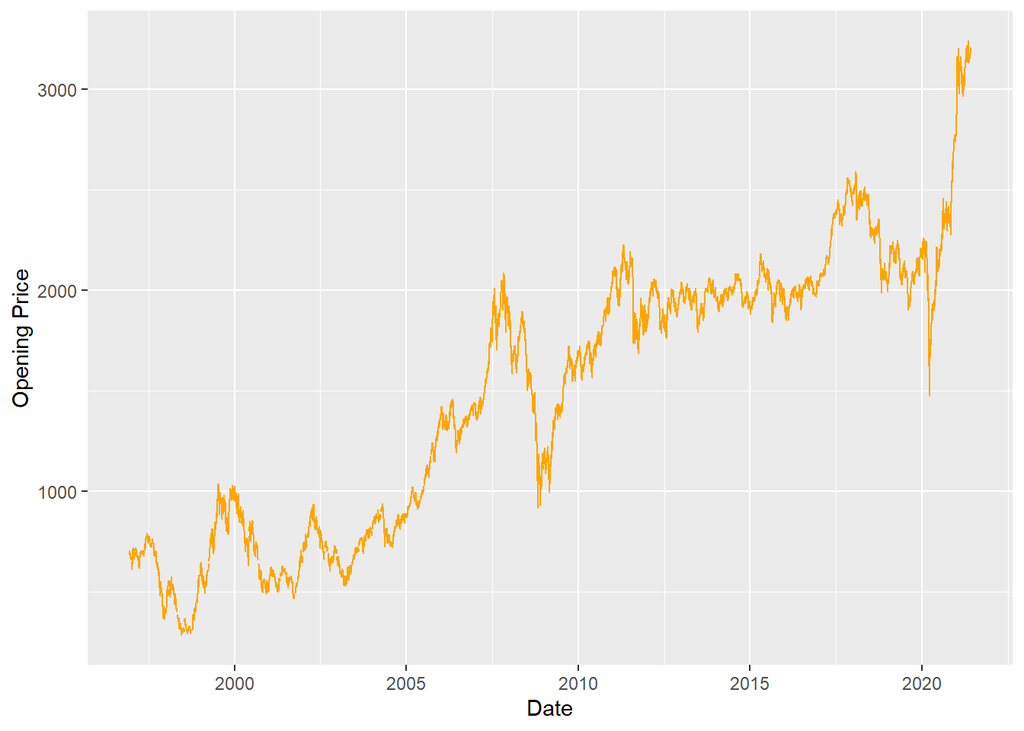

```r
dd <- read.csv("https://raw.githubusercontent.com/attaboatengsr/DATA607/main/Week9/indexData.csv", sep=",")
dd <- dd %>% filter(Index == "KS11")

ggplot(data = dd, aes(x=as.Date(dd$Date), y=as.numeric(dd$Open))) +
  geom_line(color="orange") +
  labs(x="Date", y="Opening Price")
```

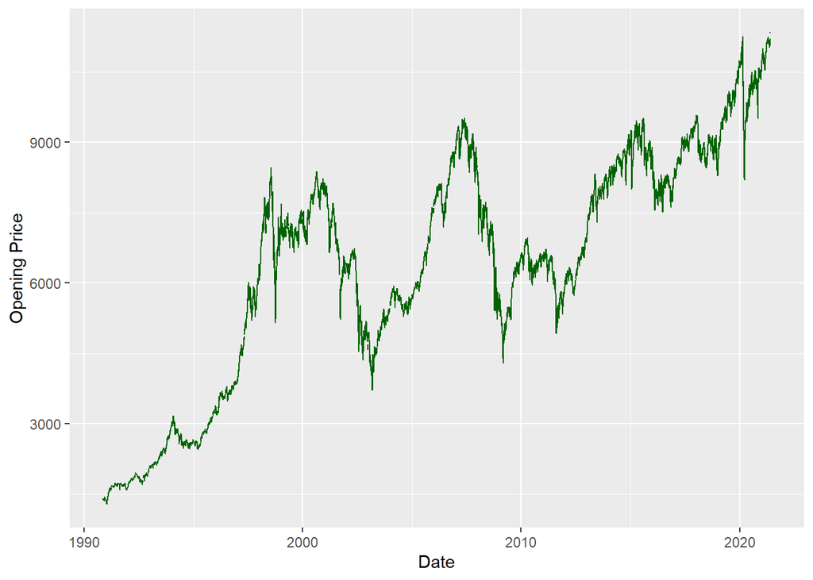

```r
dd <- read.csv("https://raw.githubusercontent.com/attaboatengsr/DATA607/main/Week9/indexData.csv", sep=",")
dd <- dd %>% filter(Index == "SSMI")

ggplot(data = dd, aes(x=as.Date(dd$Date), y=as.numeric(dd$Open))) +
  geom_line(color="darkgreen") +
  labs(x="Date", y="Opening Price")
```

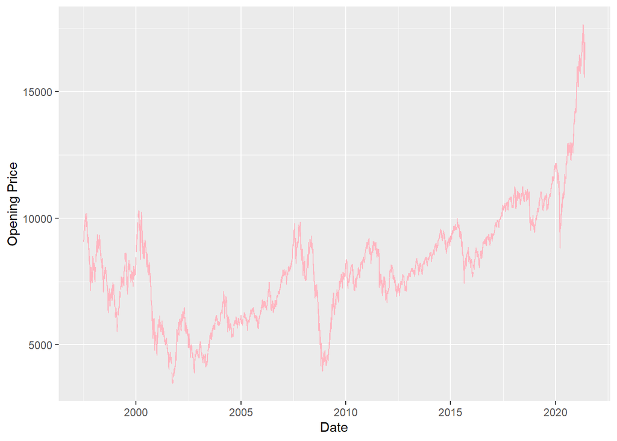

```r
dd <- read.csv("https://raw.githubusercontent.com/attaboatengsr/DATA607/main/Week9/indexData.csv", sep=",")
dd <- dd %>% filter(Index == "TWII")

ggplot(data = dd, aes(x=as.Date(dd$Date), y=as.numeric(dd$Open))) +
  geom_line(color="lightpink") +
  labs(x="Date", y="Opening Price")
```

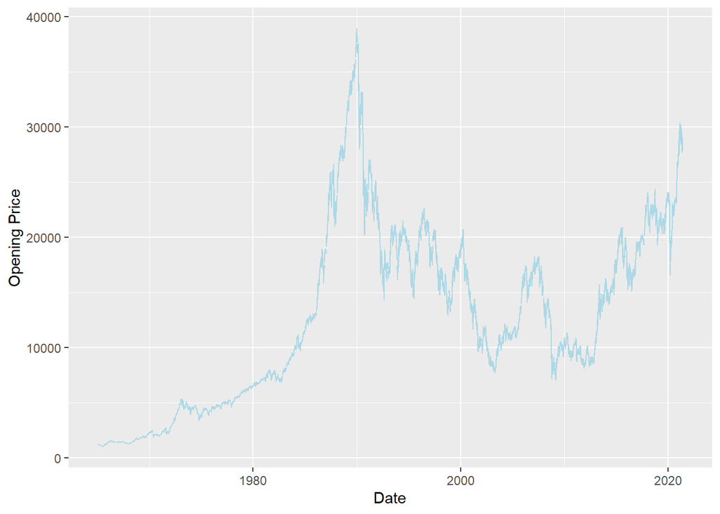

```r
dd <- read.csv("https://raw.githubusercontent.com/attaboatengsr/DATA607/main/Week9/indexData.csv", sep=",")
dd <- dd %>% filter(Index == "N225")

ggplot(data = dd, aes(x=as.Date(dd$Date), y=as.numeric(dd$Open))) +
  geom_line(color="lightblue") +
  labs(x="Date", y="Opening Price")
```

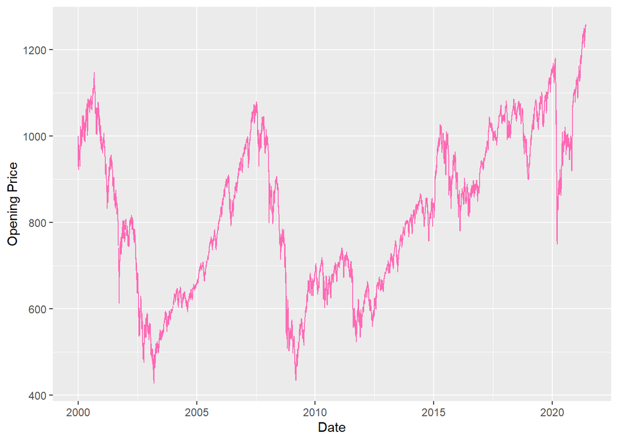

```r
dd <- read.csv("https://raw.githubusercontent.com/attaboatengsr/DATA607/main/Week9/indexData.csv", sep=",")
dd <- dd %>% filter(Index == "N100")

ggplot(data = dd, aes(x=as.Date(dd$Date), y=as.numeric(dd$Open))) +
  geom_line(color="hotpink") +
  labs(x="Date", y="Opening Price")
```